# Practical Statistical Applications in HTS

Joseph Walker

March 14, 2018

## Introduction

High Thoughput Screening runs many processes and generates large quantities of data.  
* CORE * Mutagenesis * ST4 * Rapid Fire

Currently we rely on control strains as our standards: **stable, cosistent, high replication**

Allows us to compare strain performasance and ensure our processes are within spec.

**Assay**: Fene Production from media containing sucrose as the carbon source.

**Plate Groups**: 51

**Strains**: Y967, Y4352, Y16148, Y22322, Y29438

## Examine the data

```
##            assay      plate_group_label   y_number     assay_value
##  FUVMO_sucrose:8400   PG-4702: 300      Y967  :1674   Min.   :-0.2787
##                       PG-4754: 300      Y4352 :1674   1st Qu.: 0.8594
##                       PG-4767: 300      Y16148:1674   Median : 1.3839
##                       PG-4768: 300      Y22322:1674   Mean   : 1.2624
##                       PG-4769: 300      Y29438:1704   3rd Qu.: 1.8876
##                       PG-4638: 180                    Max.   : 3.1971
##                       (Other):6720
```

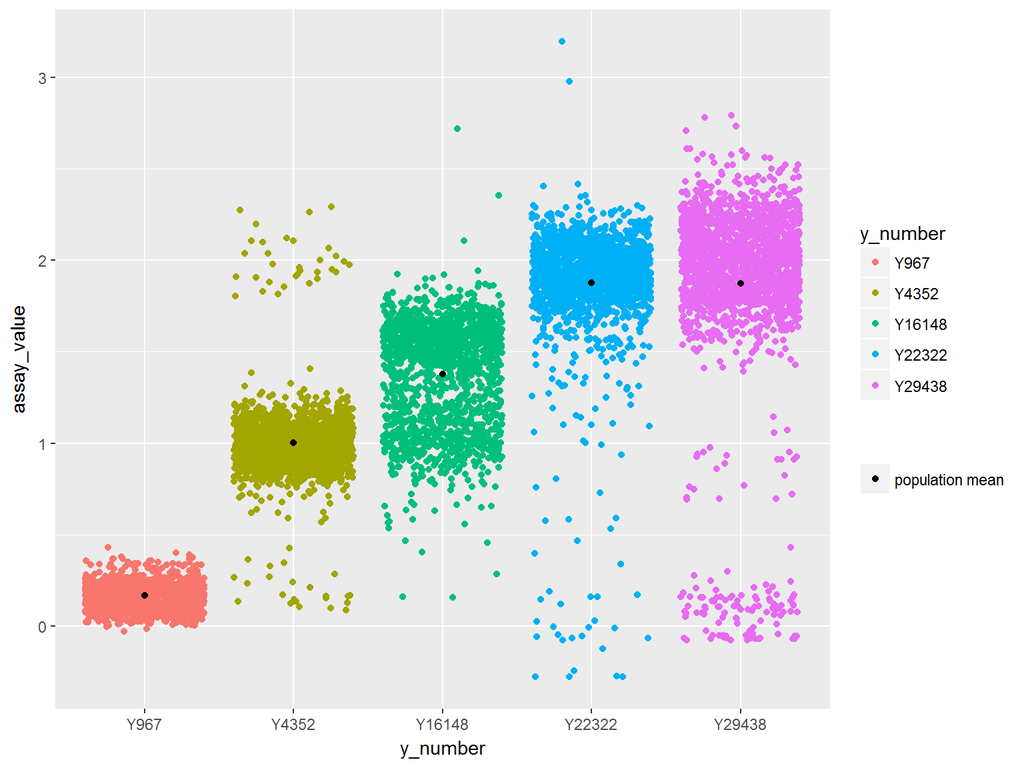

## The Central Limit Theorem

> If a sample consists of at least 30 independent observations and the data are not strongly skewed, then the distribution of the sample mean is well approximated by a normal model. Additionally, the normal approximation improves as the sample size becomes larger.

What does that really mean?

First let’s take a look at the distribution of the populations for each strain.

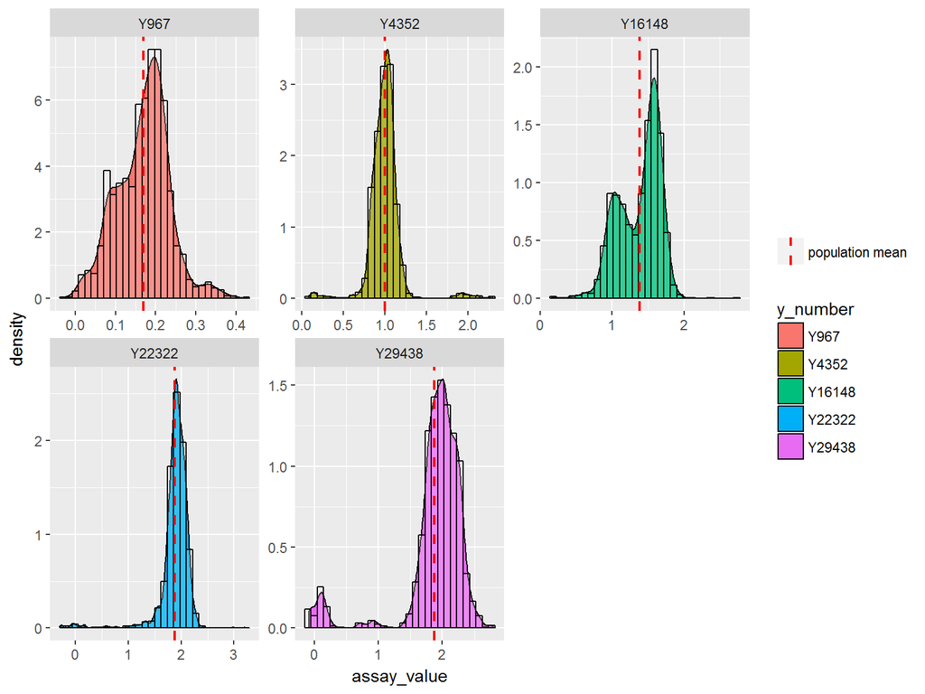

## CLT continued

In any given plate group, there are *only* 30 replicates for a given strain in the fuvmo sucrose assay.

We assume: **plate group mean = population mean**

We can replicate this by taking a sample of the data.

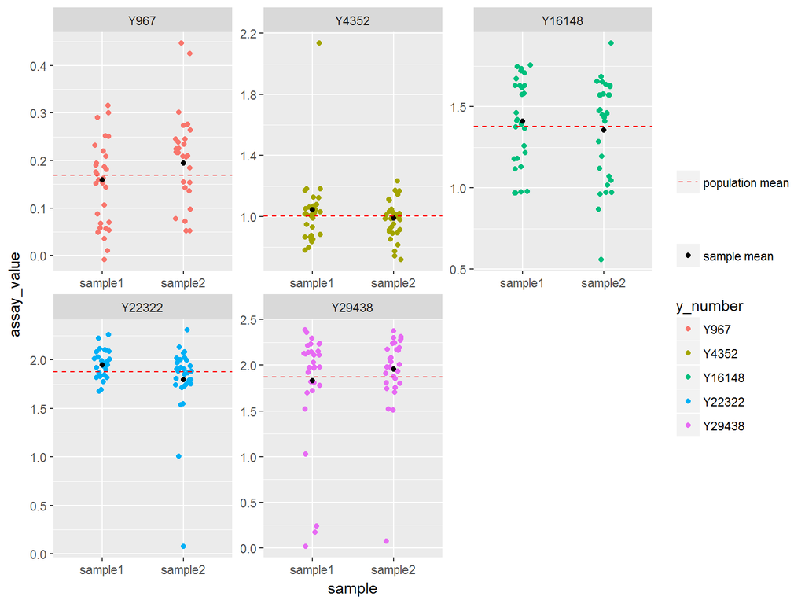

## CLT Continued

And again, we can visualize the distributions of these two samples:

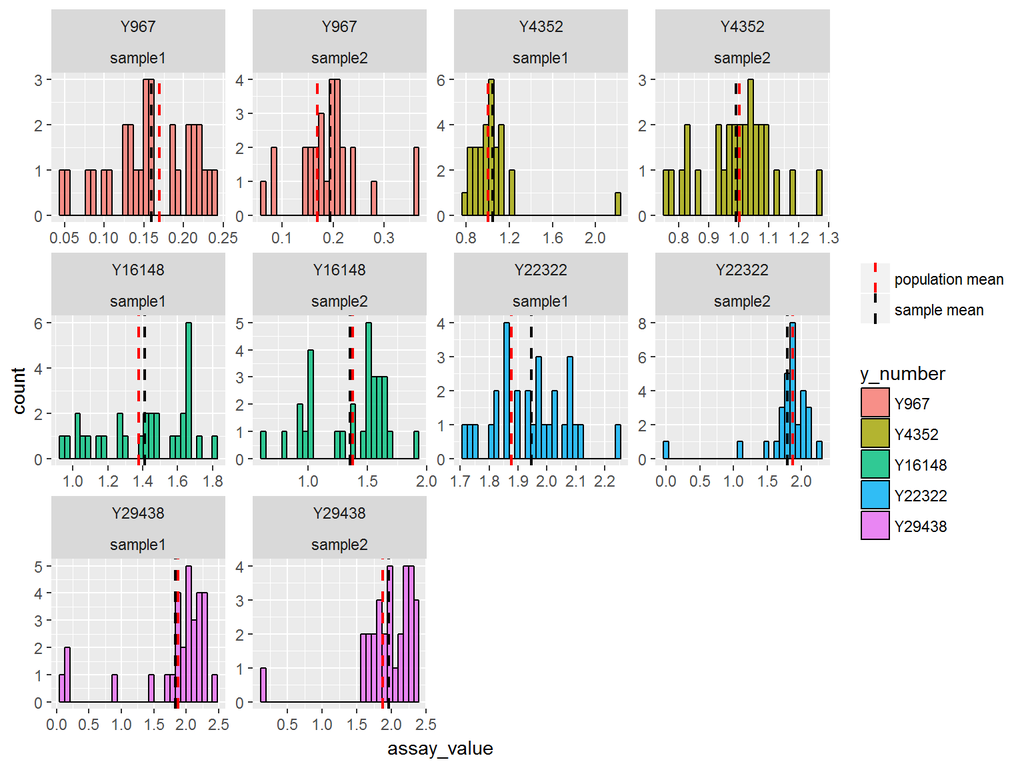

## sampling the population many times

So then, let’s break down the first concept of the CLT. If we continue sampling our population (n = 30), and we take the mean of each of those samples, we’d expect the distribution of those means to be normal, centered around the original population mean.

Let’s take 1000 samples and see if this holds.

5 strains, 30 random samples per strain, repeated 1000 times = 150,000 total samples

30,000 samples for each strain

```
##            assay        plate_group_label   y_number      assay_value
##  FUVMO_sucrose:150000   PG-4769:  5503    Y967  :30000   Min.   :-0.2787
##                         PG-4754:  5424    Y4352 :30000   1st Qu.: 0.8584
##                         PG-4767:  5359    Y16148:30000   Median : 1.3813
##                         PG-4702:  5350    Y22322:30000   Mean   : 1.2598
##                         PG-4768:  5319    Y29438:30000   3rd Qu.: 1.8870
##                         PG-4638:  3269                   Max.   : 3.1971
##                         (Other):119776
##      sample
##  1      :   150
##  2      :   150
##  3      :   150
##  4      :   150
##  5      :   150
##  6      :   150
##  (Other):149100
```

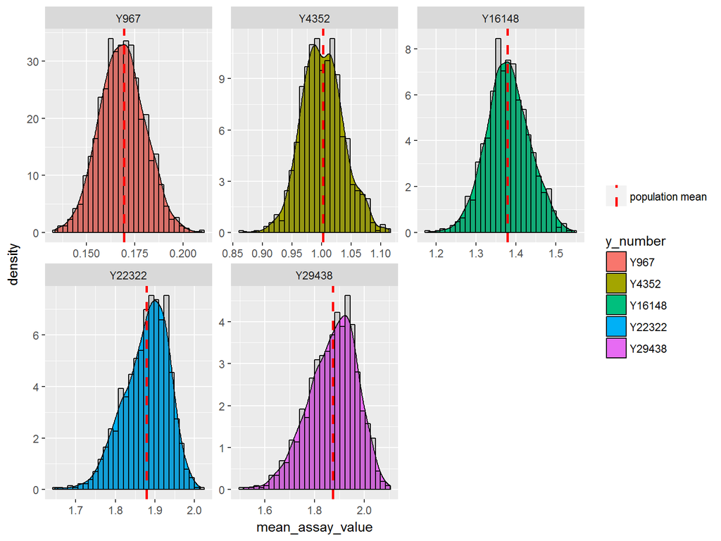

## Increasing sample size

The second key concept of the Central Limit Theorem indicates that the approximation of the normal distribution, or, our ability to approximate the population mean (The true mean) improves as the sample size increases.

Now let’s repeat what we did by taking 1000 random samples of the population for each strain assay value, but this time we’ll change the replication so that each sample has 100 observations (instead of 30).

5 strains, 100 random samples per strain, repeated 1,000 times = 500,000 total samples.

100,000 samples per strain (70,000 more each than the previous example).

```
##            assay        plate_group_label   y_number
##  FUVMO_sucrose:500000   PG-4754: 18012    Y967  :100000
##                         PG-4702: 18002    Y4352 :100000
##                         PG-4768: 17821    Y16148:100000
##                         PG-4769: 17800    Y22322:100000
##                         PG-4767: 17698    Y29438:100000
##                         PG-4638: 10492
##                         (Other):400175
##   assay_value          sample
##  Min.   :-0.2787   1      :   500
##  1st Qu.: 0.8594   2      :   500
##  Median : 1.3790   3      :   500
##  Mean   : 1.2607   4      :   500
##  3rd Qu.: 1.8870   5      :   500
##  Max.   : 3.1971   6      :   500
##                    (Other):497000
```

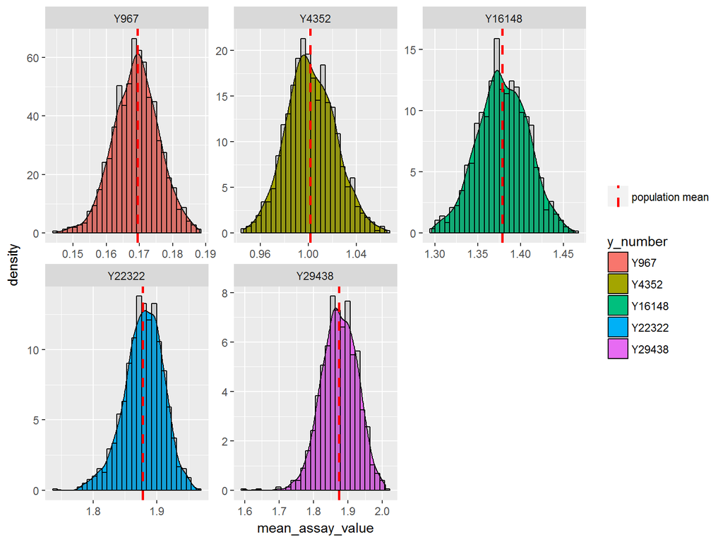